# Expansión de la CASEN sobre el CENSO (Región 01) URBANO

### 1.2 Cálculo de frecuencias

```r
tabla_con_clave_f <- tabla_con_clave[,-c(1,2,4,5,6,7,8,9,10,11,13,14,15,16,17,18,19,20),drop=FALSE]
```

```r
names(tabla_con_clave_f)[2] <- "Tipo de techo"
```

```r
# Ahora filtramos por Tipo de techo = 1.
tabla_con_clave_ff <- filter(tabla_con_clave_f, tabla_con_clave_f$`Tipo de techo` == 1)
```

```r
# Determinamos las frecuencias por zona:
b <- tabla_con_clave_ff$clave
c <- tabla_con_clave_ff$`Tipo de techo`
d <- tabla_con_clave_ff$COMUNA
cross_tab =  xtabs( ~ unlist(b) + unlist(c)+ unlist(d))
tabla <- as.data.frame(cross_tab)
d <-tabla[!(tabla$Freq == 0),]
names(d)[1] <- "zona"
d$anio <- "2017"
```

Veamos los primeros 100 registros:

```r
r3_100 <- d[c(1:100),]
kbl(r3_100) %>%
  kable_styling(bootstrap_options = c("striped", "hover")) %>%
  kable_paper() %>%
  scroll_box(width = "100%", height = "300px")
```

|  | zona | unlist.c. | unlist.d. | Freq | anio |
| --- | --- | --- | --- | --- | --- |
| 1 | 1101011001 | 1 | 1101 | 298 | 2017 |
| 2 | 1101011002 | 1 | 1101 | 95 | 2017 |
| 3 | 1101021001 | 1 | 1101 | 55 | 2017 |
| 4 | 1101021002 | 1 | 1101 | 2 | 2017 |
| 5 | 1101021003 | 1 | 1101 | 265 | 2017 |
| 6 | 1101021004 | 1 | 1101 | 178 | 2017 |
| 7 | 1101021005 | 1 | 1101 | 337 | 2017 |
| 8 | 1101031001 | 1 | 1101 | 194 | 2017 |
| 9 | 1101031002 | 1 | 1101 | 482 | 2017 |
| 10 | 1101031003 | 1 | 1101 | 328 | 2017 |
| 11 | 1101031004 | 1 | 1101 | 171 | 2017 |
| 12 | 1101041001 | 1 | 1101 | 135 | 2017 |
| 13 | 1101041002 | 1 | 1101 | 228 | 2017 |
| 14 | 1101041003 | 1 | 1101 | 235 | 2017 |
| 15 | 1101041004 | 1 | 1101 | 636 | 2017 |
| 16 | 1101041005 | 1 | 1101 | 403 | 2017 |
| 17 | 1101041006 | 1 | 1101 | 214 | 2017 |
| 18 | 1101051001 | 1 | 1101 | 364 | 2017 |
| 19 | 1101051002 | 1 | 1101 | 350 | 2017 |
| 20 | 1101051003 | 1 | 1101 | 303 | 2017 |
| 21 | 1101051004 | 1 | 1101 | 200 | 2017 |
| 22 | 1101051005 | 1 | 1101 | 269 | 2017 |
| 23 | 1101051006 | 1 | 1101 | 256 | 2017 |
| 24 | 1101061001 | 1 | 1101 | 105 | 2017 |
| 25 | 1101061002 | 1 | 1101 | 349 | 2017 |
| 26 | 1101061003 | 1 | 1101 | 259 | 2017 |
| 27 | 1101061004 | 1 | 1101 | 134 | 2017 |
| 28 | 1101061005 | 1 | 1101 | 144 | 2017 |
| 29 | 1101071001 | 1 | 1101 | 271 | 2017 |
| 30 | 1101071002 | 1 | 1101 | 453 | 2017 |

[output cut: 70 more lines]

Agregamos un cero a los códigos comunales de cuatro dígitos:

```r
codigos <- d$unlist.d.
rango <- seq(1:nrow(d))
cadena <- paste("0",codigos[rango], sep = "")
cadena <- substr(cadena,(nchar(cadena)[rango])-(4),6)
codigos <- as.data.frame(codigos)
cadena <- as.data.frame(cadena)
comuna_corr <- cbind(d,cadena)
comuna_corr <- comuna_corr[,-c(2,3),drop=FALSE]
names(comuna_corr)[4] <- "código"
r3_100 <- comuna_corr[c(1:100),]
kbl(r3_100) %>%
  kable_styling(bootstrap_options = c("striped", "hover")) %>%
  kable_paper() %>%
  scroll_box(width = "100%", height = "300px")
```

|  | zona | Freq | anio | código |
| --- | --- | --- | --- | --- |
| 1 | 1101011001 | 298 | 2017 | 01101 |
| 2 | 1101011002 | 95 | 2017 | 01101 |
| 3 | 1101021001 | 55 | 2017 | 01101 |
| 4 | 1101021002 | 2 | 2017 | 01101 |
| 5 | 1101021003 | 265 | 2017 | 01101 |
| 6 | 1101021004 | 178 | 2017 | 01101 |
| 7 | 1101021005 | 337 | 2017 | 01101 |
| 8 | 1101031001 | 194 | 2017 | 01101 |
| 9 | 1101031002 | 482 | 2017 | 01101 |
| 10 | 1101031003 | 328 | 2017 | 01101 |
| 11 | 1101031004 | 171 | 2017 | 01101 |
| 12 | 1101041001 | 135 | 2017 | 01101 |
| 13 | 1101041002 | 228 | 2017 | 01101 |
| 14 | 1101041003 | 235 | 2017 | 01101 |
| 15 | 1101041004 | 636 | 2017 | 01101 |
| 16 | 1101041005 | 403 | 2017 | 01101 |
| 17 | 1101041006 | 214 | 2017 | 01101 |
| 18 | 1101051001 | 364 | 2017 | 01101 |
| 19 | 1101051002 | 350 | 2017 | 01101 |
| 20 | 1101051003 | 303 | 2017 | 01101 |
| 21 | 1101051004 | 200 | 2017 | 01101 |
| 22 | 1101051005 | 269 | 2017 | 01101 |
| 23 | 1101051006 | 256 | 2017 | 01101 |
| 24 | 1101061001 | 105 | 2017 | 01101 |
| 25 | 1101061002 | 349 | 2017 | 01101 |
| 26 | 1101061003 | 259 | 2017 | 01101 |
| 27 | 1101061004 | 134 | 2017 | 01101 |
| 28 | 1101061005 | 144 | 2017 | 01101 |
| 29 | 1101071001 | 271 | 2017 | 01101 |
| 30 | 1101071002 | 453 | 2017 | 01101 |

[output cut: 70 more lines]

## 2 Variable CASEN

### 2.1 Tabla de ingresos expandidos

Hemos calculado ya éste valor como conclusión del punto 1.1 de [aquí](https://rpubs.com/dataintelligence/corr_casen_censo_002)

```r
h_y_m_2017_censo <- readRDS("../ingresos_expandidos_17.rds")
tablamadre <- head(h_y_m_2017_censo,50)
kbl(tablamadre) %>%
  kable_styling(bootstrap_options = c("striped", "hover")) %>%
  kable_paper() %>%
  scroll_box(width = "100%", height = "300px")
```

| código | comuna.x | promedio_i | año | comuna.y | personas | Ingresos_expandidos |
| --- | --- | --- | --- | --- | --- | --- |
| 01101 | Iquique | 354820.7 | 2017 | 1101 | 191468 | 67936815240 |
| 01107 | Alto Hospicio | 301933.4 | 2017 | 1107 | 108375 | 32722034397 |
| 01401 | Pozo Almonte | 285981.8 | 2017 | 1401 | 15711 | 4493059532 |
| 01402 | Camiña | 262850.3 | 2017 | 1402 | 1250 | 328562901 |
| 01404 | Huara | 253968.5 | 2017 | 1404 | 2730 | 693334131 |
| 01405 | Pica | 313007.5 | 2017 | 1405 | 9296 | 2909717399 |
| 02101 | Antofagasta | 347580.2 | 2017 | 2101 | 361873 | 125779893517 |
| 02102 | Mejillones | 369770.7 | 2017 | 2102 | 13467 | 4979702302 |
| 02103 | Sierra Gorda | 403458.5 | 2017 | 2103 | 10186 | 4109628188 |
| 02104 | Taltal | 364539.1 | 2017 | 2104 | 13317 | 4854566842 |
| 02201 | Calama | 409671.3 | 2017 | 2201 | 165731 | 67895226712 |
| 02203 | San Pedro de Atacama | 426592.0 | 2017 | 2203 | 10996 | 4690805471 |
| 02301 | Tocopilla | 246615.3 | 2017 | 2301 | 25186 | 6211253937 |
| 02302 | María Elena | 466266.9 | 2017 | 2302 | 6457 | 3010685220 |
| 03101 | Copiapó | 330075.2 | 2017 | 3101 | 153937 | 50810778473 |
| 03102 | Caldera | 299314.8 | 2017 | 3102 | 17662 | 5286498241 |
| 03103 | Tierra Amarilla | 314643.9 | 2017 | 3103 | 14019 | 4410992711 |
| 03201 | Chañaral | 286389.3 | 2017 | 3201 | 12219 | 3499391196 |
| 03202 | Diego de Almagro | 336256.8 | 2017 | 3202 | 13925 | 4682376047 |
| 03301 | Vallenar | 304336.7 | 2017 | 3301 | 51917 | 15800246795 |
| 03302 | Alto del Carmen | 227130.4 | 2017 | 3302 | 5299 | 1203563833 |
| 03303 | Freirina | 253086.7 | 2017 | 3303 | 7041 | 1781983257 |
| 03304 | Huasco | 287406.6 | 2017 | 3304 | 10149 | 2916889629 |
| 04101 | La Serena | 270221.9 | 2017 | 4101 | 221054 | 59733627577 |
| 04102 | Coquimbo | 261852.6 | 2017 | 4102 | 227730 | 59631700074 |
| 04103 | Andacollo | 248209.3 | 2017 | 4103 | 11044 | 2741223967 |
| 04104 | La Higuera | 228356.8 | 2017 | 4104 | 4241 | 968461330 |
| 04105 | Paiguano | 205942.1 | 2017 | 4105 | 4497 | 926121774 |
| 04106 | Vicuña | 211431.9 | 2017 | 4106 | 27771 | 5871675449 |
| 04201 | Illapel | 238674.4 | 2017 | 4201 | 30848 | 7362627007 |
| 04202 | Canela | 207933.6 | 2017 | 4202 | 9093 | 1890740321 |
| 04203 | Los Vilos | 255200.4 | 2017 | 4203 | 21382 | 5456695139 |
| 04204 | Salamanca | 242879.5 | 2017 | 4204 | 29347 | 7127783272 |
| 04301 | Ovalle | 266522.9 | 2017 | 4301 | 111272 | 29656533187 |
| 04302 | Combarbalá | 210409.7 | 2017 | 4302 | 13322 | 2803077721 |
| 04303 | Monte Patria | 211907.9 | 2017 | 4303 | 30751 | 6516380780 |
| 04304 | Punitaqui | 194997.8 | 2017 | 4304 | 10956 | 2136395349 |
| 04305 | Río Hurtado | 182027.2 | 2017 | 4305 | 4278 | 778712384 |
| 05101 | Valparaíso | 298720.7 | 2017 | 5101 | 296655 | 88616992249 |
| 05102 | Casablanca | 312802.7 | 2017 | 5102 | 26867 | 8404070481 |
| 05103 | Concón | 318496.3 | 2017 | 5103 | 42152 | 13425257057 |
| 05105 | Puchuncaví | 288737.2 | 2017 | 5105 | 18546 | 5354920887 |
| 05107 | Quintero | 316659.1 | 2017 | 5107 | 31923 | 10108709691 |
| 05109 | Viña del Mar | 337006.1 | 2017 | 5109 | 334248 | 112643604611 |
| 05301 | Los Andes | 338182.5 | 2017 | 5301 | 66708 | 22559476922 |
| 05302 | Calle Larga | 245165.4 | 2017 | 5302 | 14832 | 3636293159 |
| 05303 | Rinconada | 281633.2 | 2017 | 5303 | 10207 | 2874630315 |
| 05304 | San Esteban | 220958.4 | 2017 | 5304 | 18855 | 4166170587 |
| 05401 | La Ligua | 229623.7 | 2017 | 5401 | 35390 | 8126381563 |
| 05402 | Cabildo | 249717.7 | 2017 | 5402 | 19388 | 4841527150 |

## 3 Unión Censo-Casen

Integramos a la tabla censal de frecuencias la tabla de ingresos expandidos de la Casen.

```r
comunas_con_ing_exp = merge( x = comuna_corr, y = h_y_m_2017_censo, by = "código", all.x = TRUE)
r3_100 <- comunas_con_ing_exp[c(1:100),]
kbl(r3_100) %>%
  kable_styling(bootstrap_options = c("striped", "hover")) %>%
  kable_paper() %>%
  scroll_box(width = "100%", height = "300px")
```

| código | zona | Freq | anio | comuna.x | promedio_i | año | comuna.y | personas | Ingresos_expandidos |
| --- | --- | --- | --- | --- | --- | --- | --- | --- | --- |
| 01101 | 1101021004 | 178 | 2017 | Iquique | 354820.7 | 2017 | 1101 | 191468 | 67936815240 |
| 01101 | 1101021003 | 265 | 2017 | Iquique | 354820.7 | 2017 | 1101 | 191468 | 67936815240 |
| 01101 | 1101031003 | 328 | 2017 | Iquique | 354820.7 | 2017 | 1101 | 191468 | 67936815240 |
| 01101 | 1101021005 | 337 | 2017 | Iquique | 354820.7 | 2017 | 1101 | 191468 | 67936815240 |
| 01101 | 1101031001 | 194 | 2017 | Iquique | 354820.7 | 2017 | 1101 | 191468 | 67936815240 |
| 01101 | 1101031002 | 482 | 2017 | Iquique | 354820.7 | 2017 | 1101 | 191468 | 67936815240 |
| 01101 | 1101011001 | 298 | 2017 | Iquique | 354820.7 | 2017 | 1101 | 191468 | 67936815240 |
| 01101 | 1101011002 | 95 | 2017 | Iquique | 354820.7 | 2017 | 1101 | 191468 | 67936815240 |
| 01101 | 1101021001 | 55 | 2017 | Iquique | 354820.7 | 2017 | 1101 | 191468 | 67936815240 |
| 01101 | 1101021002 | 2 | 2017 | Iquique | 354820.7 | 2017 | 1101 | 191468 | 67936815240 |
| 01101 | 1101051001 | 364 | 2017 | Iquique | 354820.7 | 2017 | 1101 | 191468 | 67936815240 |
| 01101 | 1101051002 | 350 | 2017 | Iquique | 354820.7 | 2017 | 1101 | 191468 | 67936815240 |
| 01101 | 1101051003 | 303 | 2017 | Iquique | 354820.7 | 2017 | 1101 | 191468 | 67936815240 |
| 01101 | 1101051004 | 200 | 2017 | Iquique | 354820.7 | 2017 | 1101 | 191468 | 67936815240 |
| 01101 | 1101051005 | 269 | 2017 | Iquique | 354820.7 | 2017 | 1101 | 191468 | 67936815240 |
| 01101 | 1101051006 | 256 | 2017 | Iquique | 354820.7 | 2017 | 1101 | 191468 | 67936815240 |
| 01101 | 1101061001 | 105 | 2017 | Iquique | 354820.7 | 2017 | 1101 | 191468 | 67936815240 |
| 01101 | 1101061002 | 349 | 2017 | Iquique | 354820.7 | 2017 | 1101 | 191468 | 67936815240 |
| 01101 | 1101061003 | 259 | 2017 | Iquique | 354820.7 | 2017 | 1101 | 191468 | 67936815240 |
| 01101 | 1101061004 | 134 | 2017 | Iquique | 354820.7 | 2017 | 1101 | 191468 | 67936815240 |
| 01101 | 1101061005 | 144 | 2017 | Iquique | 354820.7 | 2017 | 1101 | 191468 | 67936815240 |
| 01101 | 1101071001 | 271 | 2017 | Iquique | 354820.7 | 2017 | 1101 | 191468 | 67936815240 |
| 01101 | 1101071002 | 453 | 2017 | Iquique | 354820.7 | 2017 | 1101 | 191468 | 67936815240 |
| 01101 | 1101071003 | 483 | 2017 | Iquique | 354820.7 | 2017 | 1101 | 191468 | 67936815240 |
| 01101 | 1101071004 | 211 | 2017 | Iquique | 354820.7 | 2017 | 1101 | 191468 | 67936815240 |
| 01101 | 1101081001 | 601 | 2017 | Iquique | 354820.7 | 2017 | 1101 | 191468 | 67936815240 |
| 01101 | 1101081002 | 469 | 2017 | Iquique | 354820.7 | 2017 | 1101 | 191468 | 67936815240 |
| 01101 | 1101081003 | 328 | 2017 | Iquique | 354820.7 | 2017 | 1101 | 191468 | 67936815240 |
| 01101 | 1101081004 | 284 | 2017 | Iquique | 354820.7 | 2017 | 1101 | 191468 | 67936815240 |
| 01101 | 1101092004 | 6 | 2017 | Iquique | 354820.7 | 2017 | 1101 | 191468 | 67936815240 |

[output cut: 70 more lines]

## 4 Proporción poblacional zonal respecto a la comunal

Del censo obtenemos la cantidad de población a nivel de zona y estimamos su proporción a nivel comunal. Ya hemos calculado ésta proporción [aquí](https://rpubs.com/dataintelligence/tabla_de_proporciones).

```r
prop_pob <- readRDS("../tabla_de_prop_pob.rds")
names(prop_pob)[1] <- "zona"
names(prop_pob)[3] <- "p_poblacional"
```

Veamos los 100 primeros registros:

```r
r3_100 <- prop_pob[c(1:100),]
kbl(r3_100) %>%
  kable_styling(bootstrap_options = c("striped", "hover")) %>%
  kable_paper() %>%
  scroll_box(width = "100%", height = "300px")
```

| zona | Freq | p_poblacional | código |
| --- | --- | --- | --- |
| 1101011001 | 2491 | 0.0130100 | 01101 |
| 1101011002 | 1475 | 0.0077036 | 01101 |
| 1101021001 | 1003 | 0.0052385 | 01101 |
| 1101021002 | 54 | 0.0002820 | 01101 |
| 1101021003 | 2895 | 0.0151200 | 01101 |
| 1101021004 | 2398 | 0.0125243 | 01101 |
| 1101021005 | 4525 | 0.0236332 | 01101 |
| 1101031001 | 2725 | 0.0142321 | 01101 |
| 1101031002 | 3554 | 0.0185618 | 01101 |
| 1101031003 | 5246 | 0.0273988 | 01101 |
| 1101031004 | 3389 | 0.0177001 | 01101 |
| 1101041001 | 1800 | 0.0094010 | 01101 |
| 1101041002 | 2538 | 0.0132555 | 01101 |
| 1101041003 | 3855 | 0.0201339 | 01101 |
| 1101041004 | 5663 | 0.0295767 | 01101 |
| 1101041005 | 4162 | 0.0217373 | 01101 |
| 1101041006 | 2689 | 0.0140441 | 01101 |
| 1101051001 | 3296 | 0.0172144 | 01101 |
| 1101051002 | 4465 | 0.0233198 | 01101 |
| 1101051003 | 4656 | 0.0243174 | 01101 |
| 1101051004 | 2097 | 0.0109522 | 01101 |
| 1101051005 | 3569 | 0.0186402 | 01101 |
| 1101051006 | 2741 | 0.0143157 | 01101 |
| 1101061001 | 1625 | 0.0084871 | 01101 |
| 1101061002 | 4767 | 0.0248971 | 01101 |
| 1101061003 | 4826 | 0.0252053 | 01101 |
| 1101061004 | 4077 | 0.0212934 | 01101 |
| 1101061005 | 2166 | 0.0113126 | 01101 |
| 1101071001 | 2324 | 0.0121378 | 01101 |
| 1101071002 | 2801 | 0.0146291 | 01101 |

[output cut: 70 more lines]

## 5 Ingreso medio

Deseamos el valor del ingreso promedio a nivel comunal, pero expandido a nivel zonal. Ésta información está contenida en el campo promedio_i de la tabla obtenida en el punto 3.

```r
r3_100 <- comunas_con_ing_exp[c(1:100),]
kbl(r3_100) %>%
  kable_styling(bootstrap_options = c("striped", "hover")) %>%
  kable_paper() %>%
  scroll_box(width = "100%", height = "300px")
```

| código | zona | Freq | anio | comuna.x | promedio_i | año | comuna.y | personas | Ingresos_expandidos |
| --- | --- | --- | --- | --- | --- | --- | --- | --- | --- |
| 01101 | 1101021004 | 178 | 2017 | Iquique | 354820.7 | 2017 | 1101 | 191468 | 67936815240 |
| 01101 | 1101021003 | 265 | 2017 | Iquique | 354820.7 | 2017 | 1101 | 191468 | 67936815240 |
| 01101 | 1101031003 | 328 | 2017 | Iquique | 354820.7 | 2017 | 1101 | 191468 | 67936815240 |
| 01101 | 1101021005 | 337 | 2017 | Iquique | 354820.7 | 2017 | 1101 | 191468 | 67936815240 |
| 01101 | 1101031001 | 194 | 2017 | Iquique | 354820.7 | 2017 | 1101 | 191468 | 67936815240 |
| 01101 | 1101031002 | 482 | 2017 | Iquique | 354820.7 | 2017 | 1101 | 191468 | 67936815240 |
| 01101 | 1101011001 | 298 | 2017 | Iquique | 354820.7 | 2017 | 1101 | 191468 | 67936815240 |
| 01101 | 1101011002 | 95 | 2017 | Iquique | 354820.7 | 2017 | 1101 | 191468 | 67936815240 |
| 01101 | 1101021001 | 55 | 2017 | Iquique | 354820.7 | 2017 | 1101 | 191468 | 67936815240 |
| 01101 | 1101021002 | 2 | 2017 | Iquique | 354820.7 | 2017 | 1101 | 191468 | 67936815240 |
| 01101 | 1101051001 | 364 | 2017 | Iquique | 354820.7 | 2017 | 1101 | 191468 | 67936815240 |
| 01101 | 1101051002 | 350 | 2017 | Iquique | 354820.7 | 2017 | 1101 | 191468 | 67936815240 |
| 01101 | 1101051003 | 303 | 2017 | Iquique | 354820.7 | 2017 | 1101 | 191468 | 67936815240 |
| 01101 | 1101051004 | 200 | 2017 | Iquique | 354820.7 | 2017 | 1101 | 191468 | 67936815240 |
| 01101 | 1101051005 | 269 | 2017 | Iquique | 354820.7 | 2017 | 1101 | 191468 | 67936815240 |
| 01101 | 1101051006 | 256 | 2017 | Iquique | 354820.7 | 2017 | 1101 | 191468 | 67936815240 |
| 01101 | 1101061001 | 105 | 2017 | Iquique | 354820.7 | 2017 | 1101 | 191468 | 67936815240 |
| 01101 | 1101061002 | 349 | 2017 | Iquique | 354820.7 | 2017 | 1101 | 191468 | 67936815240 |
| 01101 | 1101061003 | 259 | 2017 | Iquique | 354820.7 | 2017 | 1101 | 191468 | 67936815240 |
| 01101 | 1101061004 | 134 | 2017 | Iquique | 354820.7 | 2017 | 1101 | 191468 | 67936815240 |
| 01101 | 1101061005 | 144 | 2017 | Iquique | 354820.7 | 2017 | 1101 | 191468 | 67936815240 |
| 01101 | 1101071001 | 271 | 2017 | Iquique | 354820.7 | 2017 | 1101 | 191468 | 67936815240 |
| 01101 | 1101071002 | 453 | 2017 | Iquique | 354820.7 | 2017 | 1101 | 191468 | 67936815240 |
| 01101 | 1101071003 | 483 | 2017 | Iquique | 354820.7 | 2017 | 1101 | 191468 | 67936815240 |
| 01101 | 1101071004 | 211 | 2017 | Iquique | 354820.7 | 2017 | 1101 | 191468 | 67936815240 |
| 01101 | 1101081001 | 601 | 2017 | Iquique | 354820.7 | 2017 | 1101 | 191468 | 67936815240 |
| 01101 | 1101081002 | 469 | 2017 | Iquique | 354820.7 | 2017 | 1101 | 191468 | 67936815240 |
| 01101 | 1101081003 | 328 | 2017 | Iquique | 354820.7 | 2017 | 1101 | 191468 | 67936815240 |
| 01101 | 1101081004 | 284 | 2017 | Iquique | 354820.7 | 2017 | 1101 | 191468 | 67936815240 |
| 01101 | 1101092004 | 6 | 2017 | Iquique | 354820.7 | 2017 | 1101 | 191468 | 67936815240 |

[output cut: 70 more lines]

## 6 Ingreso promedio expandido por zona (**multi_pob**)

En éste momento vamos a construir nuestra variable dependiente de regresión aplicando la siguiente fórmula:

$$multi\_pob = promedio\_i \cdot personas \cdot p\_poblacional$$

Para ello integramos a la tabla de ingresos expandidos a nivel zonal (punto 3) la tabla de proporciones poblacionales zonales respecto al total comunal (punto 4) :

```r
h_y_m_comuna_corr_01 = merge( x = comunas_con_ing_exp, y = prop_pob, by = "zona", all.x = TRUE)
tablamadre <- head(h_y_m_comuna_corr_01,100)
kbl(tablamadre) %>%
  kable_styling(bootstrap_options = c("striped", "hover")) %>%
  kable_paper() %>%
  scroll_box(width = "100%", height = "300px")
```

| zona | código.x | Freq.x | anio | comuna.x | promedio_i | año | comuna.y | personas | Ingresos_expandidos | Freq.y | p_poblacional | código.y |
| --- | --- | --- | --- | --- | --- | --- | --- | --- | --- | --- | --- | --- |
| 1101011001 | 01101 | 298 | 2017 | Iquique | 354820.7 | 2017 | 1101 | 191468 | 67936815240 | 2491 | 0.0130100 | 01101 |
| 1101011002 | 01101 | 95 | 2017 | Iquique | 354820.7 | 2017 | 1101 | 191468 | 67936815240 | 1475 | 0.0077036 | 01101 |
| 1101021001 | 01101 | 55 | 2017 | Iquique | 354820.7 | 2017 | 1101 | 191468 | 67936815240 | 1003 | 0.0052385 | 01101 |
| 1101021002 | 01101 | 2 | 2017 | Iquique | 354820.7 | 2017 | 1101 | 191468 | 67936815240 | 54 | 0.0002820 | 01101 |
| 1101021003 | 01101 | 265 | 2017 | Iquique | 354820.7 | 2017 | 1101 | 191468 | 67936815240 | 2895 | 0.0151200 | 01101 |
| 1101021004 | 01101 | 178 | 2017 | Iquique | 354820.7 | 2017 | 1101 | 191468 | 67936815240 | 2398 | 0.0125243 | 01101 |
| 1101021005 | 01101 | 337 | 2017 | Iquique | 354820.7 | 2017 | 1101 | 191468 | 67936815240 | 4525 | 0.0236332 | 01101 |
| 1101031001 | 01101 | 194 | 2017 | Iquique | 354820.7 | 2017 | 1101 | 191468 | 67936815240 | 2725 | 0.0142321 | 01101 |
| 1101031002 | 01101 | 482 | 2017 | Iquique | 354820.7 | 2017 | 1101 | 191468 | 67936815240 | 3554 | 0.0185618 | 01101 |
| 1101031003 | 01101 | 328 | 2017 | Iquique | 354820.7 | 2017 | 1101 | 191468 | 67936815240 | 5246 | 0.0273988 | 01101 |
| 1101031004 | 01101 | 171 | 2017 | Iquique | 354820.7 | 2017 | 1101 | 191468 | 67936815240 | 3389 | 0.0177001 | 01101 |
| 1101041001 | 01101 | 135 | 2017 | Iquique | 354820.7 | 2017 | 1101 | 191468 | 67936815240 | 1800 | 0.0094010 | 01101 |
| 1101041002 | 01101 | 228 | 2017 | Iquique | 354820.7 | 2017 | 1101 | 191468 | 67936815240 | 2538 | 0.0132555 | 01101 |
| 1101041003 | 01101 | 235 | 2017 | Iquique | 354820.7 | 2017 | 1101 | 191468 | 67936815240 | 3855 | 0.0201339 | 01101 |
| 1101041004 | 01101 | 636 | 2017 | Iquique | 354820.7 | 2017 | 1101 | 191468 | 67936815240 | 5663 | 0.0295767 | 01101 |
| 1101041005 | 01101 | 403 | 2017 | Iquique | 354820.7 | 2017 | 1101 | 191468 | 67936815240 | 4162 | 0.0217373 | 01101 |
| 1101041006 | 01101 | 214 | 2017 | Iquique | 354820.7 | 2017 | 1101 | 191468 | 67936815240 | 2689 | 0.0140441 | 01101 |
| 1101051001 | 01101 | 364 | 2017 | Iquique | 354820.7 | 2017 | 1101 | 191468 | 67936815240 | 3296 | 0.0172144 | 01101 |
| 1101051002 | 01101 | 350 | 2017 | Iquique | 354820.7 | 2017 | 1101 | 191468 | 67936815240 | 4465 | 0.0233198 | 01101 |
| 1101051003 | 01101 | 303 | 2017 | Iquique | 354820.7 | 2017 | 1101 | 191468 | 67936815240 | 4656 | 0.0243174 | 01101 |
| 1101051004 | 01101 | 200 | 2017 | Iquique | 354820.7 | 2017 | 1101 | 191468 | 67936815240 | 2097 | 0.0109522 | 01101 |
| 1101051005 | 01101 | 269 | 2017 | Iquique | 354820.7 | 2017 | 1101 | 191468 | 67936815240 | 3569 | 0.0186402 | 01101 |
| 1101051006 | 01101 | 256 | 2017 | Iquique | 354820.7 | 2017 | 1101 | 191468 | 67936815240 | 2741 | 0.0143157 | 01101 |
| 1101061001 | 01101 | 105 | 2017 | Iquique | 354820.7 | 2017 | 1101 | 191468 | 67936815240 | 1625 | 0.0084871 | 01101 |
| 1101061002 | 01101 | 349 | 2017 | Iquique | 354820.7 | 2017 | 1101 | 191468 | 67936815240 | 4767 | 0.0248971 | 01101 |
| 1101061003 | 01101 | 259 | 2017 | Iquique | 354820.7 | 2017 | 1101 | 191468 | 67936815240 | 4826 | 0.0252053 | 01101 |
| 1101061004 | 01101 | 134 | 2017 | Iquique | 354820.7 | 2017 | 1101 | 191468 | 67936815240 | 4077 | 0.0212934 | 01101 |
| 1101061005 | 01101 | 144 | 2017 | Iquique | 354820.7 | 2017 | 1101 | 191468 | 67936815240 | 2166 | 0.0113126 | 01101 |
| 1101071001 | 01101 | 271 | 2017 | Iquique | 354820.7 | 2017 | 1101 | 191468 | 67936815240 | 2324 | 0.0121378 | 01101 |
| 1101071002 | 01101 | 453 | 2017 | Iquique | 354820.7 | 2017 | 1101 | 191468 | 67936815240 | 2801 | 0.0146291 | 01101 |

[output cut: 70 more lines]

Hacemos la multiplicación que queda almacenada en la variable **multi_pob**:

```r
h_y_m_comuna_corr_01$multi_pob <- h_y_m_comuna_corr_01$promedio_i * h_y_m_comuna_corr_01$personas * h_y_m_comuna_corr_01$p_poblacional
tablamadre <- head(h_y_m_comuna_corr_01,100)
kbl(tablamadre) %>%
  kable_styling(bootstrap_options = c("striped", "hover")) %>%
  kable_paper() %>%
  scroll_box(width = "100%", height = "300px")
```

| zona | código.x | Freq.x | anio | comuna.x | promedio_i | año | comuna.y | personas | Ingresos_expandidos | Freq.y | p_poblacional | código.y | multi_pob |
| --- | --- | --- | --- | --- | --- | --- | --- | --- | --- | --- | --- | --- | --- |
| 1101011001 | 01101 | 298 | 2017 | Iquique | 354820.7 | 2017 | 1101 | 191468 | 67936815240 | 2491 | 0.0130100 | 01101 | 883858435 |
| 1101011002 | 01101 | 95 | 2017 | Iquique | 354820.7 | 2017 | 1101 | 191468 | 67936815240 | 1475 | 0.0077036 | 01101 | 523360575 |
| 1101021001 | 01101 | 55 | 2017 | Iquique | 354820.7 | 2017 | 1101 | 191468 | 67936815240 | 1003 | 0.0052385 | 01101 | 355885191 |
| 1101021002 | 01101 | 2 | 2017 | Iquique | 354820.7 | 2017 | 1101 | 191468 | 67936815240 | 54 | 0.0002820 | 01101 | 19160319 |
| 1101021003 | 01101 | 265 | 2017 | Iquique | 354820.7 | 2017 | 1101 | 191468 | 67936815240 | 2895 | 0.0151200 | 01101 | 1027206009 |
| 1101021004 | 01101 | 178 | 2017 | Iquique | 354820.7 | 2017 | 1101 | 191468 | 67936815240 | 2398 | 0.0125243 | 01101 | 850860107 |
| 1101021005 | 01101 | 337 | 2017 | Iquique | 354820.7 | 2017 | 1101 | 191468 | 67936815240 | 4525 | 0.0236332 | 01101 | 1605563796 |
| 1101031001 | 01101 | 194 | 2017 | Iquique | 354820.7 | 2017 | 1101 | 191468 | 67936815240 | 2725 | 0.0142321 | 01101 | 966886485 |
| 1101031002 | 01101 | 482 | 2017 | Iquique | 354820.7 | 2017 | 1101 | 191468 | 67936815240 | 3554 | 0.0185618 | 01101 | 1261032869 |
| 1101031003 | 01101 | 328 | 2017 | Iquique | 354820.7 | 2017 | 1101 | 191468 | 67936815240 | 5246 | 0.0273988 | 01101 | 1861389542 |
| 1101031004 | 01101 | 171 | 2017 | Iquique | 354820.7 | 2017 | 1101 | 191468 | 67936815240 | 3389 | 0.0177001 | 01101 | 1202487449 |
| 1101041001 | 01101 | 135 | 2017 | Iquique | 354820.7 | 2017 | 1101 | 191468 | 67936815240 | 1800 | 0.0094010 | 01101 | 638677311 |
| 1101041002 | 01101 | 228 | 2017 | Iquique | 354820.7 | 2017 | 1101 | 191468 | 67936815240 | 2538 | 0.0132555 | 01101 | 900535009 |
| 1101041003 | 01101 | 235 | 2017 | Iquique | 354820.7 | 2017 | 1101 | 191468 | 67936815240 | 3855 | 0.0201339 | 01101 | 1367833908 |
| 1101041004 | 01101 | 636 | 2017 | Iquique | 354820.7 | 2017 | 1101 | 191468 | 67936815240 | 5663 | 0.0295767 | 01101 | 2009349785 |
| 1101041005 | 01101 | 403 | 2017 | Iquique | 354820.7 | 2017 | 1101 | 191468 | 67936815240 | 4162 | 0.0217373 | 01101 | 1476763872 |
| 1101041006 | 01101 | 214 | 2017 | Iquique | 354820.7 | 2017 | 1101 | 191468 | 67936815240 | 2689 | 0.0140441 | 01101 | 954112939 |
| 1101051001 | 01101 | 364 | 2017 | Iquique | 354820.7 | 2017 | 1101 | 191468 | 67936815240 | 3296 | 0.0172144 | 01101 | 1169489121 |
| 1101051002 | 01101 | 350 | 2017 | Iquique | 354820.7 | 2017 | 1101 | 191468 | 67936815240 | 4465 | 0.0233198 | 01101 | 1584274553 |
| 1101051003 | 01101 | 303 | 2017 | Iquique | 354820.7 | 2017 | 1101 | 191468 | 67936815240 | 4656 | 0.0243174 | 01101 | 1652045312 |
| 1101051004 | 01101 | 200 | 2017 | Iquique | 354820.7 | 2017 | 1101 | 191468 | 67936815240 | 2097 | 0.0109522 | 01101 | 744059068 |
| 1101051005 | 01101 | 269 | 2017 | Iquique | 354820.7 | 2017 | 1101 | 191468 | 67936815240 | 3569 | 0.0186402 | 01101 | 1266355180 |
| 1101051006 | 01101 | 256 | 2017 | Iquique | 354820.7 | 2017 | 1101 | 191468 | 67936815240 | 2741 | 0.0143157 | 01101 | 972563617 |
| 1101061001 | 01101 | 105 | 2017 | Iquique | 354820.7 | 2017 | 1101 | 191468 | 67936815240 | 1625 | 0.0084871 | 01101 | 576583684 |
| 1101061002 | 01101 | 349 | 2017 | Iquique | 354820.7 | 2017 | 1101 | 191468 | 67936815240 | 4767 | 0.0248971 | 01101 | 1691430413 |
| 1101061003 | 01101 | 259 | 2017 | Iquique | 354820.7 | 2017 | 1101 | 191468 | 67936815240 | 4826 | 0.0252053 | 01101 | 1712364836 |
| 1101061004 | 01101 | 134 | 2017 | Iquique | 354820.7 | 2017 | 1101 | 191468 | 67936815240 | 4077 | 0.0212934 | 01101 | 1446604110 |
| 1101061005 | 01101 | 144 | 2017 | Iquique | 354820.7 | 2017 | 1101 | 191468 | 67936815240 | 2166 | 0.0113126 | 01101 | 768541698 |
| 1101071001 | 01101 | 271 | 2017 | Iquique | 354820.7 | 2017 | 1101 | 191468 | 67936815240 | 2324 | 0.0121378 | 01101 | 824603373 |
| 1101071002 | 01101 | 453 | 2017 | Iquique | 354820.7 | 2017 | 1101 | 191468 | 67936815240 | 2801 | 0.0146291 | 01101 | 993852860 |

[output cut: 70 more lines]

## 7 Análisis de regresión

Aplicaremos un análisis de regresión donde:

$$Y(dependiente) = ingreso \ expandido \ por \ zona \ (multi\_pob)$$

$$X(independiente) = frecuencia \ de \ población \ que \ posee \ la \ variable \ Censal \ respecto \ a \ la \ zona \ (Freq.x)$$

### 7.1 Diagrama de dispersión loess

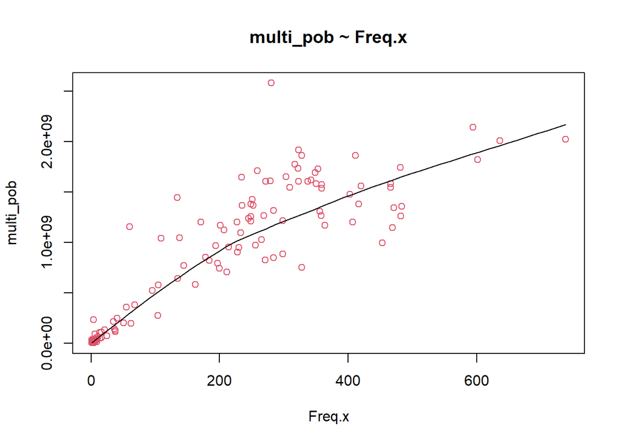

```r
scatter.smooth(x=h_y_m_comuna_corr_01$Freq.x, y=h_y_m_comuna_corr_01$multi_pob, main="multi_pob ~ Freq.x",
     xlab = "Freq.x",
     ylab = "multi_pob",
           col = 2)
```

### 7.2 Outliers

Hemos demostrado en el punto 5.7.2 de [aquí](https://rpubs.com/dataintelligence/expansion_viviendas_001) que la exclusión de ouliers no genera ninguna mejora en el modelo de regresión.

### 7.3 Modelo lineal

Aplicaremos un análisis de regresión lineal del ingreso expandido por zona sobre las frecuencias de respuestas zonales.

```r
linearMod <- lm( multi_pob~(Freq.x) , data=h_y_m_comuna_corr_01)
summary(linearMod)
```

```
##
## Call:
## lm(formula = multi_pob ~ (Freq.x), data = h_y_m_comuna_corr_01)
##
## Residuals:
##        Min         1Q     Median         3Q        Max
## -778713702 -109149227  -94148848  116773259 1453761808
##
## Coefficients:
##              Estimate Std. Error t value Pr(>|t|)
## (Intercept) 103753651   31169768   3.329  0.00109 **
## Freq.x        3656119     135103  27.062  < 2e-16 ***
## ---
## Signif. codes:  0 '***' 0.001 '**' 0.01 '*' 0.05 '.' 0.1 ' ' 1
##
## Residual standard error: 294300000 on 158 degrees of freedom
##   (7 observations deleted due to missingness)
## Multiple R-squared:  0.8225, Adjusted R-squared:  0.8214
## F-statistic: 732.3 on 1 and 158 DF,  p-value: < 2.2e-16
```

### 7.4 Gráfica de la recta de regresión lineal

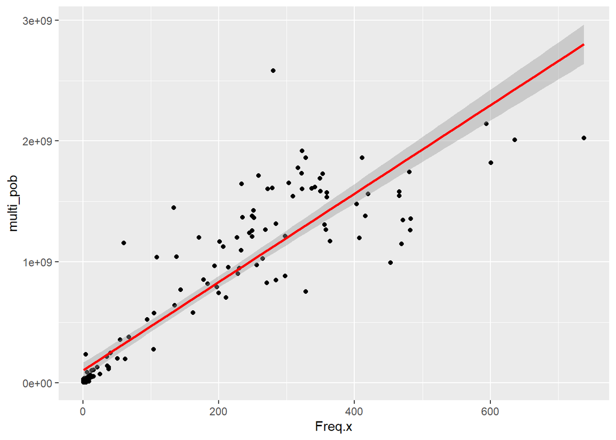

```r
ggplot(h_y_m_comuna_corr_01, aes(x = Freq.x , y = multi_pob)) +
  geom_point() +
  stat_smooth(method = "lm", col = "red")
```

Si bien obtenemos nuestro modelo lineal da cuenta del 0.8214 de la variabilidad de los datos de respuesta en torno a su media, modelos alternativos pueden ofrecernos una explicación de la variable dependiente aún mayor.

## 8 Modelos alternativos

### 8.1 Modelo cuadrático

$$\hat Y = \beta_0 + \beta_1 X^2$$

```r
linearMod <- lm( multi_pob~(Freq.x^2) , data=h_y_m_comuna_corr_01)
summary(linearMod)
```

```
##
## Call:
## lm(formula = multi_pob ~ (Freq.x^2), data = h_y_m_comuna_corr_01)
##
## Residuals:
##        Min         1Q     Median         3Q        Max
## -778713702 -109149227  -94148848  116773259 1453761808
##
## Coefficients:
##              Estimate Std. Error t value Pr(>|t|)
## (Intercept) 103753651   31169768   3.329  0.00109 **
## Freq.x        3656119     135103  27.062  < 2e-16 ***
## ---
## Signif. codes:  0 '***' 0.001 '**' 0.01 '*' 0.05 '.' 0.1 ' ' 1
##
## Residual standard error: 294300000 on 158 degrees of freedom
##   (7 observations deleted due to missingness)
## Multiple R-squared:  0.8225, Adjusted R-squared:  0.8214
## F-statistic: 732.3 on 1 and 158 DF,  p-value: < 2.2e-16
```

### 8.2 Modelo cúbico

$$\hat Y = \beta_0 + \beta_1 X^3$$

```r
linearMod <- lm( multi_pob~(Freq.x^3) , data=h_y_m_comuna_corr_01)
summary(linearMod)
```

```
##
## Call:
## lm(formula = multi_pob ~ (Freq.x^3), data = h_y_m_comuna_corr_01)
##
## Residuals:
##        Min         1Q     Median         3Q        Max
## -778713702 -109149227  -94148848  116773259 1453761808
##
## Coefficients:
##              Estimate Std. Error t value Pr(>|t|)
## (Intercept) 103753651   31169768   3.329  0.00109 **
## Freq.x        3656119     135103  27.062  < 2e-16 ***
## ---
## Signif. codes:  0 '***' 0.001 '**' 0.01 '*' 0.05 '.' 0.1 ' ' 1
##
## Residual standard error: 294300000 on 158 degrees of freedom
##   (7 observations deleted due to missingness)
## Multiple R-squared:  0.8225, Adjusted R-squared:  0.8214
## F-statistic: 732.3 on 1 and 158 DF,  p-value: < 2.2e-16
```

### 8.3 Modelo logarítmico

$$\hat Y = \beta_0 + \beta_1 ln X$$

```r
linearMod <- lm( multi_pob~log(Freq.x) , data=h_y_m_comuna_corr_01)
summary(linearMod)
```

```
##
## Call:
## lm(formula = multi_pob ~ log(Freq.x), data = h_y_m_comuna_corr_01)
##
## Residuals:
##        Min         1Q     Median         3Q        Max
## -702369877 -240830930    2750951  266230472 1339912491
##
## Coefficients:
##               Estimate Std. Error t value Pr(>|t|)
## (Intercept) -261556818   46451524  -5.631 8.01e-08 ***
## log(Freq.x)  266713265   11141523  23.939  < 2e-16 ***
## ---
## Signif. codes:  0 '***' 0.001 '**' 0.01 '*' 0.05 '.' 0.1 ' ' 1
##
## Residual standard error: 324700000 on 158 degrees of freedom
##   (7 observations deleted due to missingness)
## Multiple R-squared:  0.7839, Adjusted R-squared:  0.7825
## F-statistic: 573.1 on 1 and 158 DF,  p-value: < 2.2e-16
```

### 8.4 Modelo exponencial

$$\hat Y = \beta_0 + \beta_1 e^X$$

No es aplicable sin una transformación pues los valores elevados a $e$ de Freq.x tienden a infinito.

### 8.5 Modelo con raíz cuadrada

$$\hat Y = \beta_0 + \beta_1 \sqrt {X}$$

```r
linearMod <- lm( multi_pob~sqrt(Freq.x) , data=h_y_m_comuna_corr_01)
summary(linearMod)
```

```
##
## Call:
## lm(formula = multi_pob ~ sqrt(Freq.x), data = h_y_m_comuna_corr_01)
##
## Residuals:
##        Min         1Q     Median         3Q        Max
## -643406415 -124632045    3480125   68294852 1323291761
##
## Coefficients:
##                Estimate Std. Error t value Pr(>|t|)
## (Intercept)  -136885689   30447720  -4.496 1.33e-05 ***
## sqrt(Freq.x)   83356602    2457090  33.925  < 2e-16 ***
## ---
## Signif. codes:  0 '***' 0.001 '**' 0.01 '*' 0.05 '.' 0.1 ' ' 1
##
## Residual standard error: 242700000 on 158 degrees of freedom
##   (7 observations deleted due to missingness)
## Multiple R-squared:  0.8793, Adjusted R-squared:  0.8785
## F-statistic:  1151 on 1 and 158 DF,  p-value: < 2.2e-16
```

### 8.6 Modelo raíz-raíz

$$\hat Y = {\beta_0}^2 + 2 \beta_0 \beta_1 \sqrt{X}+ \beta_1^2 X$$

```r
linearMod <- lm( sqrt(multi_pob)~sqrt(Freq.x) , data=h_y_m_comuna_corr_01)
summary(linearMod)
```

```
##
## Call:
## lm(formula = sqrt(multi_pob) ~ sqrt(Freq.x), data = h_y_m_comuna_corr_01)
##
## Residuals:
##      Min       1Q   Median       3Q      Max
## -11631.6  -2362.9   -872.9   1970.3  17362.9
##
## Coefficients:
##              Estimate Std. Error t value Pr(>|t|)
## (Intercept)   1422.21     551.15    2.58   0.0108 *
## sqrt(Freq.x)  1960.87      44.48   44.09   <2e-16 ***
## ---
## Signif. codes:  0 '***' 0.001 '**' 0.01 '*' 0.05 '.' 0.1 ' ' 1
##
## Residual standard error: 4393 on 158 degrees of freedom
##   (7 observations deleted due to missingness)
## Multiple R-squared:  0.9248, Adjusted R-squared:  0.9243
## F-statistic:  1944 on 1 and 158 DF,  p-value: < 2.2e-16
```

### 8.7 Modelo log-raíz

$$\hat Y = e^{\beta_0 + \beta_1 \sqrt{X}}$$

```r
linearMod <- lm( log(multi_pob)~sqrt(Freq.x) , data=h_y_m_comuna_corr_01)
summary(linearMod)
```

```
##
## Call:
## lm(formula = log(multi_pob) ~ sqrt(Freq.x), data = h_y_m_comuna_corr_01)
##
## Residuals:
##     Min      1Q  Median      3Q     Max
## -2.1592 -0.6229  0.1736  0.6357  2.5838
##
## Coefficients:
##               Estimate Std. Error t value Pr(>|t|)
## (Intercept)  16.167220   0.116383  138.91   <2e-16 ***
## sqrt(Freq.x)  0.273133   0.009392   29.08   <2e-16 ***
## ---
## Signif. codes:  0 '***' 0.001 '**' 0.01 '*' 0.05 '.' 0.1 ' ' 1
##
## Residual standard error: 0.9277 on 158 degrees of freedom
##   (7 observations deleted due to missingness)
## Multiple R-squared:  0.8426, Adjusted R-squared:  0.8416
## F-statistic: 845.7 on 1 and 158 DF,  p-value: < 2.2e-16
```

### 8.8 Modelo raíz-log

$$\hat Y = {\beta_0}^2 + 2 \beta_0 \beta_1 \ln{X}+ \beta_1^2 ln^2X$$

```r
linearMod <- lm( sqrt(multi_pob)~log(Freq.x) , data=h_y_m_comuna_corr_01)
summary(linearMod)
```

```
##
## Call:
## lm(formula = sqrt(multi_pob) ~ log(Freq.x), data = h_y_m_comuna_corr_01)
##
## Residuals:
##      Min       1Q   Median       3Q      Max
## -11365.4  -4266.6     99.9   4088.3  16384.4
##
## Coefficients:
##             Estimate Std. Error t value Pr(>|t|)
## (Intercept)  -2441.2      737.8  -3.309  0.00116 **
## log(Freq.x)   6542.0      177.0  36.966  < 2e-16 ***
## ---
## Signif. codes:  0 '***' 0.001 '**' 0.01 '*' 0.05 '.' 0.1 ' ' 1
##
## Residual standard error: 5158 on 158 degrees of freedom
##   (7 observations deleted due to missingness)
## Multiple R-squared:  0.8964, Adjusted R-squared:  0.8957
## F-statistic:  1367 on 1 and 158 DF,  p-value: < 2.2e-16
```

### 8.9 Modelo log-log

$$\hat Y = e^{\beta_0+\beta_1 ln{X}}$$

```r
linearMod <- lm( log(multi_pob)~log(Freq.x) , data=h_y_m_comuna_corr_01)
summary(linearMod)
```

```
##
## Call:
## lm(formula = log(multi_pob) ~ log(Freq.x), data = h_y_m_comuna_corr_01)
##
## Residuals:
##      Min       1Q   Median       3Q      Max
## -2.12838 -0.32952 -0.01881  0.30228  2.49967
##
## Coefficients:
##             Estimate Std. Error t value Pr(>|t|)
## (Intercept) 15.42700    0.09206   167.6   <2e-16 ***
## log(Freq.x)  0.96940    0.02208    43.9   <2e-16 ***
## ---
## Signif. codes:  0 '***' 0.001 '**' 0.01 '*' 0.05 '.' 0.1 ' ' 1
##
## Residual standard error: 0.6436 on 158 degrees of freedom
##   (7 observations deleted due to missingness)
## Multiple R-squared:  0.9242, Adjusted R-squared:  0.9238
## F-statistic:  1927 on 1 and 158 DF,  p-value: < 2.2e-16
```

## 9 Modelo raíz-raíz (**r-r**)

Es éste el modelo que nos entrega el mayor coeficiente de determinación de todos (0.9243).

### 9.1 Diagrama de dispersión sobre **r-r**

Desplegamos una curva suavizada por loess en el diagrama de dispersión.

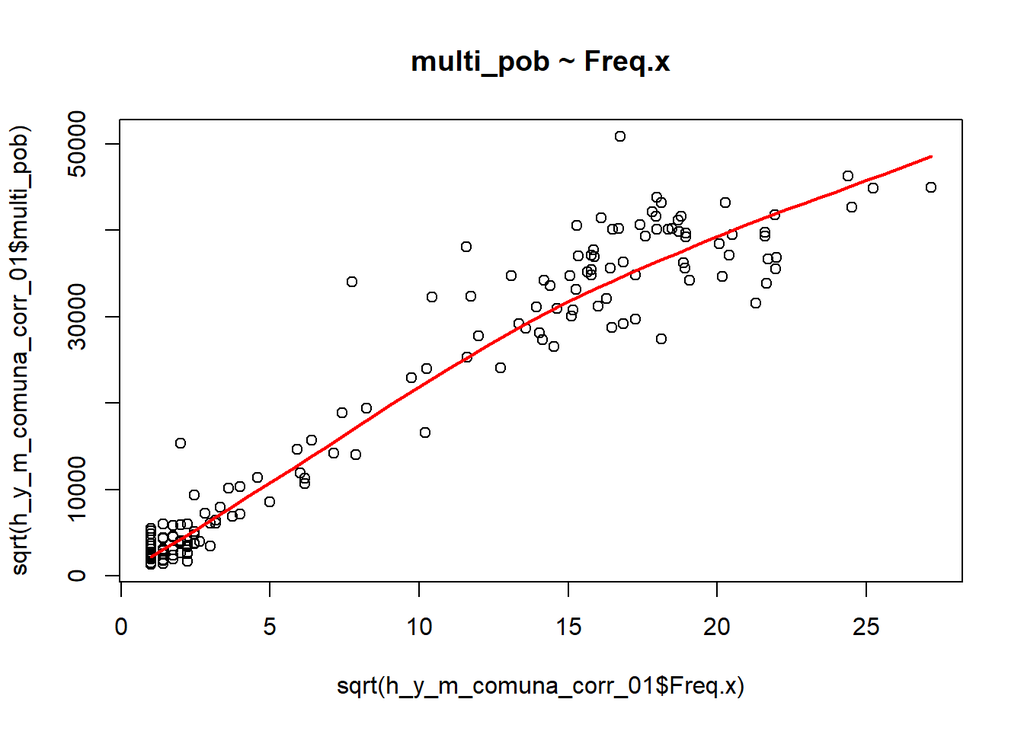

```r
scatter.smooth(x=sqrt(h_y_m_comuna_corr_01$Freq.x), y=sqrt(h_y_m_comuna_corr_01$multi_pob), lpars = list(col = "red", lwd = 2, lty = 1), main="multi_pob ~ Freq.x")
```

### 9.2 Modelo **r-r**

Observemos nuevamente el resultado sobre **r-r**.

```r
linearMod <- lm(sqrt( multi_pob)~sqrt(Freq.x) , data=h_y_m_comuna_corr_01)
summary(linearMod)
```

```
##
## Call:
## lm(formula = sqrt(multi_pob) ~ sqrt(Freq.x), data = h_y_m_comuna_corr_01)
##
## Residuals:
##      Min       1Q   Median       3Q      Max
## -11631.6  -2362.9   -872.9   1970.3  17362.9
##
## Coefficients:
##              Estimate Std. Error t value Pr(>|t|)
## (Intercept)   1422.21     551.15    2.58   0.0108 *
## sqrt(Freq.x)  1960.87      44.48   44.09   <2e-16 ***
## ---
## Signif. codes:  0 '***' 0.001 '**' 0.01 '*' 0.05 '.' 0.1 ' ' 1
##
## Residual standard error: 4393 on 158 degrees of freedom
##   (7 observations deleted due to missingness)
## Multiple R-squared:  0.9248, Adjusted R-squared:  0.9243
## F-statistic:  1944 on 1 and 158 DF,  p-value: < 2.2e-16
```

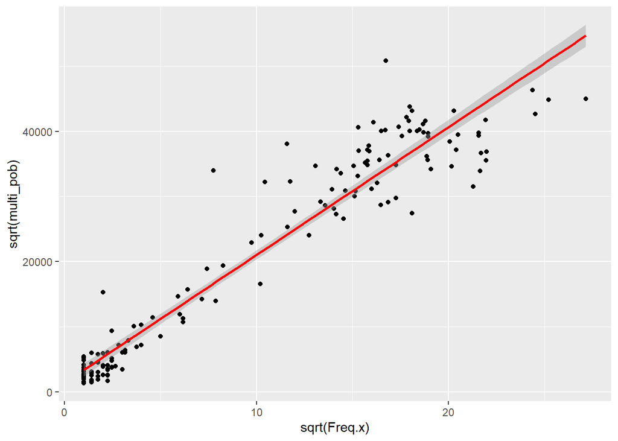

```r
ggplot(h_y_m_comuna_corr_01, aes(x = sqrt(Freq.x) , y = sqrt(multi_pob))) +
  geom_point() +
  stat_smooth(method = "lm", col = "red")
```

### 9.3 Análisis de residuos

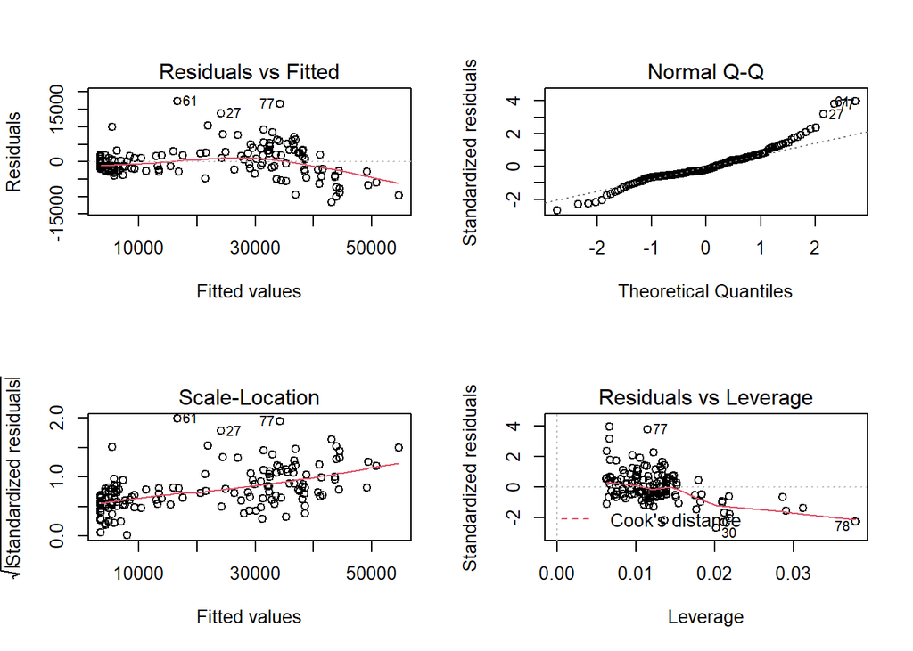

```r
par(mfrow = c (2,2))
plot(linearMod)
```

## 10 Aplicación la regresión a los valores de la variable a nivel de zona

Esta nueva variable se llamará: est_ing

```r
h_y_m_comuna_corr_01$est_ing <- 1422.21^2 + 1422.21* 1960.87* sqrt(h_y_m_comuna_corr_01$Freq.x)+1960.87 ^2*h_y_m_comuna_corr_01$Freq.x

r3_100 <- h_y_m_comuna_corr_01[c(1:100),]
kbl(r3_100) %>%
  kable_styling(bootstrap_options = c("striped", "hover")) %>%
  kable_paper() %>%
  scroll_box(width = "100%", height = "300px")
```

| zona | código.x | Freq.x | anio | comuna.x | promedio_i | año | comuna.y | personas | Ingresos_expandidos | Freq.y | p_poblacional | código.y | multi_pob | est_ing |
| --- | --- | --- | --- | --- | --- | --- | --- | --- | --- | --- | --- | --- | --- | --- |
| 1101011001 | 01101 | 298 | 2017 | Iquique | 354820.7 | 2017 | 1101 | 191468 | 67936815240 | 2491 | 0.0130100 | 01101 | 883858435 | 1195977622 |
| 1101011002 | 01101 | 95 | 2017 | Iquique | 354820.7 | 2017 | 1101 | 191468 | 67936815240 | 1475 | 0.0077036 | 01101 | 523360575 | 394480298 |
| 1101021001 | 01101 | 55 | 2017 | Iquique | 354820.7 | 2017 | 1101 | 191468 | 67936815240 | 1003 | 0.0052385 | 01101 | 355885191 | 234180359 |
| 1101021002 | 01101 | 2 | 2017 | Iquique | 354820.7 | 2017 | 1101 | 191468 | 67936815240 | 54 | 0.0002820 | 01101 | 19160319 | 13656618 |
| 1101021003 | 01101 | 265 | 2017 | Iquique | 354820.7 | 2017 | 1101 | 191468 | 67936815240 | 2895 | 0.0151200 | 01101 | 1027206009 | 1066348507 |
| 1101021004 | 01101 | 178 | 2017 | Iquique | 354820.7 | 2017 | 1101 | 191468 | 67936815240 | 2398 | 0.0125243 | 01101 | 850860107 | 723641485 |
| 1101021005 | 01101 | 337 | 2017 | Iquique | 354820.7 | 2017 | 1101 | 191468 | 67936815240 | 4525 | 0.0236332 | 01101 | 1605563796 | 1348986433 |
| 1101031001 | 01101 | 194 | 2017 | Iquique | 354820.7 | 2017 | 1101 | 191468 | 67936815240 | 2725 | 0.0142321 | 01101 | 966886485 | 786797902 |
| 1101031002 | 01101 | 482 | 2017 | Iquique | 354820.7 | 2017 | 1101 | 191468 | 67936815240 | 3554 | 0.0185618 | 01101 | 1261032869 | 1916544082 |
| 1101031003 | 01101 | 328 | 2017 | Iquique | 354820.7 | 2017 | 1101 | 191468 | 67936815240 | 5246 | 0.0273988 | 01101 | 1861389542 | 1313693094 |
| 1101031004 | 01101 | 171 | 2017 | Iquique | 354820.7 | 2017 | 1101 | 191468 | 67936815240 | 3389 | 0.0177001 | 01101 | 1202487449 | 695987475 |
| 1101041001 | 01101 | 135 | 2017 | Iquique | 354820.7 | 2017 | 1101 | 191468 | 67936815240 | 1800 | 0.0094010 | 01101 | 638677311 | 553501754 |
| 1101041002 | 01101 | 228 | 2017 | Iquique | 354820.7 | 2017 | 1101 | 191468 | 67936815240 | 2538 | 0.0132555 | 01101 | 900535009 | 920794712 |
| 1101041003 | 01101 | 235 | 2017 | Iquique | 354820.7 | 2017 | 1101 | 191468 | 67936815240 | 3855 | 0.0201339 | 01101 | 1367833908 | 948351321 |
| 1101041004 | 01101 | 636 | 2017 | Iquique | 354820.7 | 2017 | 1101 | 191468 | 67936815240 | 5663 | 0.0295767 | 01101 | 2009349785 | 2517779853 |
| 1101041005 | 01101 | 403 | 2017 | Iquique | 354820.7 | 2017 | 1101 | 191468 | 67936815240 | 4162 | 0.0217373 | 01101 | 1476763872 | 1607546323 |
| 1101041006 | 01101 | 214 | 2017 | Iquique | 354820.7 | 2017 | 1101 | 191468 | 67936815240 | 2689 | 0.0140441 | 01101 | 954112939 | 865651241 |
| 1101051001 | 01101 | 364 | 2017 | Iquique | 354820.7 | 2017 | 1101 | 191468 | 67936815240 | 3296 | 0.0172144 | 01101 | 1169489121 | 1454813062 |
| 1101051002 | 01101 | 350 | 2017 | Iquique | 354820.7 | 2017 | 1101 | 191468 | 67936815240 | 4465 | 0.0233198 | 01101 | 1584274553 | 1399949675 |
| 1101051003 | 01101 | 303 | 2017 | Iquique | 354820.7 | 2017 | 1101 | 191468 | 67936815240 | 4656 | 0.0243174 | 01101 | 1652045312 | 1215604870 |
| 1101051004 | 01101 | 200 | 2017 | Iquique | 354820.7 | 2017 | 1101 | 191468 | 67936815240 | 2097 | 0.0109522 | 01101 | 744059068 | 810464061 |
| 1101051005 | 01101 | 269 | 2017 | Iquique | 354820.7 | 2017 | 1101 | 191468 | 67936815240 | 3569 | 0.0186402 | 01101 | 1266355180 | 1082069894 |
| 1101051006 | 01101 | 256 | 2017 | Iquique | 354820.7 | 2017 | 1101 | 191468 | 67936815240 | 2741 | 0.0143157 | 01101 | 972563617 | 1030965840 |
| 1101061001 | 01101 | 105 | 2017 | Iquique | 354820.7 | 2017 | 1101 | 191468 | 67936815240 | 1625 | 0.0084871 | 01101 | 576583684 | 434325231 |
| 1101061002 | 01101 | 349 | 2017 | Iquique | 354820.7 | 2017 | 1101 | 191468 | 67936815240 | 4767 | 0.0248971 | 01101 | 1691430413 | 1396030078 |
| 1101061003 | 01101 | 259 | 2017 | Iquique | 354820.7 | 2017 | 1101 | 191468 | 67936815240 | 4826 | 0.0252053 | 01101 | 1712364836 | 1042761559 |
| 1101061004 | 01101 | 134 | 2017 | Iquique | 354820.7 | 2017 | 1101 | 191468 | 67936815240 | 4077 | 0.0212934 | 01101 | 1446604110 | 549536511 |
| 1101061005 | 01101 | 144 | 2017 | Iquique | 354820.7 | 2017 | 1101 | 191468 | 67936815240 | 2166 | 0.0113126 | 01101 | 768541698 | 589169515 |
| 1101071001 | 01101 | 271 | 2017 | Iquique | 354820.7 | 2017 | 1101 | 191468 | 67936815240 | 2324 | 0.0121378 | 01101 | 824603373 | 1089929635 |
| 1101071002 | 01101 | 453 | 2017 | Iquique | 354820.7 | 2017 | 1101 | 191468 | 67936815240 | 2801 | 0.0146291 | 01101 | 993852860 | 1803168326 |

[output cut: 70 more lines]

## 11 División del valor estimado entre la población total de la zona para obtener el ingreso medio por zona

$$Ingreso \_ Medio\_zona = est\_ing / (personas * p\_poblacional)$$

```r
h_y_m_comuna_corr_01$ing_medio_zona <- h_y_m_comuna_corr_01$est_ing  /( h_y_m_comuna_corr_01$personas  * h_y_m_comuna_corr_01$p_poblacional)

r3_100 <- h_y_m_comuna_corr_01[c(1:100),]
kbl(r3_100) %>%
  kable_styling(bootstrap_options = c("striped", "hover")) %>%
  kable_paper() %>%
  scroll_box(width = "100%", height = "300px")
```

| zona | código.x | Freq.x | anio | comuna.x | promedio_i | año | comuna.y | personas | Ingresos_expandidos | Freq.y | p_poblacional | código.y | multi_pob | est_ing | ing_medio_zona |
| --- | --- | --- | --- | --- | --- | --- | --- | --- | --- | --- | --- | --- | --- | --- | --- |
| 1101011001 | 01101 | 298 | 2017 | Iquique | 354820.7 | 2017 | 1101 | 191468 | 67936815240 | 2491 | 0.0130100 | 01101 | 883858435 | 1195977622 | 480119.5 |
| 1101011002 | 01101 | 95 | 2017 | Iquique | 354820.7 | 2017 | 1101 | 191468 | 67936815240 | 1475 | 0.0077036 | 01101 | 523360575 | 394480298 | 267444.3 |
| 1101021001 | 01101 | 55 | 2017 | Iquique | 354820.7 | 2017 | 1101 | 191468 | 67936815240 | 1003 | 0.0052385 | 01101 | 355885191 | 234180359 | 233479.9 |
| 1101021002 | 01101 | 2 | 2017 | Iquique | 354820.7 | 2017 | 1101 | 191468 | 67936815240 | 54 | 0.0002820 | 01101 | 19160319 | 13656618 | 252900.3 |
| 1101021003 | 01101 | 265 | 2017 | Iquique | 354820.7 | 2017 | 1101 | 191468 | 67936815240 | 2895 | 0.0151200 | 01101 | 1027206009 | 1066348507 | 368341.5 |
| 1101021004 | 01101 | 178 | 2017 | Iquique | 354820.7 | 2017 | 1101 | 191468 | 67936815240 | 2398 | 0.0125243 | 01101 | 850860107 | 723641485 | 301768.8 |
| 1101021005 | 01101 | 337 | 2017 | Iquique | 354820.7 | 2017 | 1101 | 191468 | 67936815240 | 4525 | 0.0236332 | 01101 | 1605563796 | 1348986433 | 298118.5 |
| 1101031001 | 01101 | 194 | 2017 | Iquique | 354820.7 | 2017 | 1101 | 191468 | 67936815240 | 2725 | 0.0142321 | 01101 | 966886485 | 786797902 | 288733.2 |
| 1101031002 | 01101 | 482 | 2017 | Iquique | 354820.7 | 2017 | 1101 | 191468 | 67936815240 | 3554 | 0.0185618 | 01101 | 1261032869 | 1916544082 | 539264.0 |
| 1101031003 | 01101 | 328 | 2017 | Iquique | 354820.7 | 2017 | 1101 | 191468 | 67936815240 | 5246 | 0.0273988 | 01101 | 1861389542 | 1313693094 | 250418.1 |
| 1101031004 | 01101 | 171 | 2017 | Iquique | 354820.7 | 2017 | 1101 | 191468 | 67936815240 | 3389 | 0.0177001 | 01101 | 1202487449 | 695987475 | 205366.6 |
| 1101041001 | 01101 | 135 | 2017 | Iquique | 354820.7 | 2017 | 1101 | 191468 | 67936815240 | 1800 | 0.0094010 | 01101 | 638677311 | 553501754 | 307501.0 |
| 1101041002 | 01101 | 228 | 2017 | Iquique | 354820.7 | 2017 | 1101 | 191468 | 67936815240 | 2538 | 0.0132555 | 01101 | 900535009 | 920794712 | 362803.3 |
| 1101041003 | 01101 | 235 | 2017 | Iquique | 354820.7 | 2017 | 1101 | 191468 | 67936815240 | 3855 | 0.0201339 | 01101 | 1367833908 | 948351321 | 246005.5 |
| 1101041004 | 01101 | 636 | 2017 | Iquique | 354820.7 | 2017 | 1101 | 191468 | 67936815240 | 5663 | 0.0295767 | 01101 | 2009349785 | 2517779853 | 444601.8 |
| 1101041005 | 01101 | 403 | 2017 | Iquique | 354820.7 | 2017 | 1101 | 191468 | 67936815240 | 4162 | 0.0217373 | 01101 | 1476763872 | 1607546323 | 386243.7 |
| 1101041006 | 01101 | 214 | 2017 | Iquique | 354820.7 | 2017 | 1101 | 191468 | 67936815240 | 2689 | 0.0140441 | 01101 | 954112939 | 865651241 | 321923.1 |
| 1101051001 | 01101 | 364 | 2017 | Iquique | 354820.7 | 2017 | 1101 | 191468 | 67936815240 | 3296 | 0.0172144 | 01101 | 1169489121 | 1454813062 | 441387.5 |
| 1101051002 | 01101 | 350 | 2017 | Iquique | 354820.7 | 2017 | 1101 | 191468 | 67936815240 | 4465 | 0.0233198 | 01101 | 1584274553 | 1399949675 | 313538.6 |
| 1101051003 | 01101 | 303 | 2017 | Iquique | 354820.7 | 2017 | 1101 | 191468 | 67936815240 | 4656 | 0.0243174 | 01101 | 1652045312 | 1215604870 | 261083.5 |
| 1101051004 | 01101 | 200 | 2017 | Iquique | 354820.7 | 2017 | 1101 | 191468 | 67936815240 | 2097 | 0.0109522 | 01101 | 744059068 | 810464061 | 386487.4 |
| 1101051005 | 01101 | 269 | 2017 | Iquique | 354820.7 | 2017 | 1101 | 191468 | 67936815240 | 3569 | 0.0186402 | 01101 | 1266355180 | 1082069894 | 303185.7 |
| 1101051006 | 01101 | 256 | 2017 | Iquique | 354820.7 | 2017 | 1101 | 191468 | 67936815240 | 2741 | 0.0143157 | 01101 | 972563617 | 1030965840 | 376127.6 |
| 1101061001 | 01101 | 105 | 2017 | Iquique | 354820.7 | 2017 | 1101 | 191468 | 67936815240 | 1625 | 0.0084871 | 01101 | 576583684 | 434325231 | 267277.1 |
| 1101061002 | 01101 | 349 | 2017 | Iquique | 354820.7 | 2017 | 1101 | 191468 | 67936815240 | 4767 | 0.0248971 | 01101 | 1691430413 | 1396030078 | 292853.0 |
| 1101061003 | 01101 | 259 | 2017 | Iquique | 354820.7 | 2017 | 1101 | 191468 | 67936815240 | 4826 | 0.0252053 | 01101 | 1712364836 | 1042761559 | 216071.6 |
| 1101061004 | 01101 | 134 | 2017 | Iquique | 354820.7 | 2017 | 1101 | 191468 | 67936815240 | 4077 | 0.0212934 | 01101 | 1446604110 | 549536511 | 134789.4 |
| 1101061005 | 01101 | 144 | 2017 | Iquique | 354820.7 | 2017 | 1101 | 191468 | 67936815240 | 2166 | 0.0113126 | 01101 | 768541698 | 589169515 | 272008.1 |
| 1101071001 | 01101 | 271 | 2017 | Iquique | 354820.7 | 2017 | 1101 | 191468 | 67936815240 | 2324 | 0.0121378 | 01101 | 824603373 | 1089929635 | 468988.7 |
| 1101071002 | 01101 | 453 | 2017 | Iquique | 354820.7 | 2017 | 1101 | 191468 | 67936815240 | 2801 | 0.0146291 | 01101 | 993852860 | 1803168326 | 643758.8 |

[output cut: 70 more lines]

Guardamos:

```r
saveRDS(h_y_m_comuna_corr_01, "casen_censo_region_01.rds")
```

## 12 Referencias

https://rpubs.com/osoramirez/316691

https://dataintelligencechile.shinyapps.io/casenfinal

Manual_de_usuario_Censo_2017_16R.pdf

http://www.censo2017.cl/microdatos/

Censo de Población y Vivienda

https://www.ine.cl/estadisticas/sociales/censos-de-poblacion-y-vivienda/poblacion-y-vivienda

http://r-statistics.co/Linear-Regression.html